# EasyVisa_Full_Code_Notebook

## Problem Statement

### Business Context

Business communities in the United States are facing high demand for human resources, but one of the constant challenges is identifying and attracting the right talent, which is perhaps the most important element in remaining competitive. Companies in the United States look for hard-working, talented, and qualified individuals both locally as well as abroad.

The Immigration and Nationality Act (INA) of the US permits foreign workers to come to the United States to work on either a temporary or permanent basis. The act also protects US workers against adverse impacts on their wages or working conditions by ensuring US employers' compliance with statutory requirements when they hire foreign workers to fill workforce shortages. The immigration programs are administered by the Office of Foreign Labor Certification (OFLC).

OFLC processes job certification applications for employers seeking to bring foreign workers into the United States and grants certifications in those cases where employers can demonstrate that there are not sufficient US workers available to perform the work at wages that meet or exceed the wage paid for the occupation in the area of intended employment.

### Objective

In FY 2016, the OFLC processed 775,979 employer applications for 1,699,957 positions for temporary and permanent labor certifications. This was a nine percent increase in the overall number of processed applications from the previous year. The process of reviewing every case is becoming a tedious task as the number of applicants is increasing every year.

The increasing number of applicants every year calls for a Machine Learning based solution that can help in shortlisting the candidates having higher chances of VISA approval. OFLC has hired the firm EasyVisa for data-driven solutions. You as a data scientist at EasyVisa have to analyze the data provided and, with the help of a classification model:

- Facilitate the process of visa approvals.
- Recommend a suitable profile for the applicants for whom the visa should be certified or denied based on the drivers that significantly influence the case status.

### Data Description

The data contains the different attributes of employee and the employer. The detailed data dictionary is given below.

- case_id: ID of each visa application
- continent: Information of continent the employee
- education_of_employee: Information of education of the employee
- has_job_experience: Does the employee has any job experience? Y= Yes; N = No
- requires_job_training: Does the employee require any job training? Y = Yes; N = No
- no_of_employees: Number of employees in the employer's company
- yr_of_estab: Year in which the employer's company was established
- region_of_employment: Information of foreign worker's intended region of employment in the US.
- prevailing_wage: Average wage paid to similarly employed workers in a specific occupation in the area of intended employment. The purpose of the prevailing wage is to ensure that the foreign worker is not underpaid compared to other workers offering the same or similar service in the same area of employment.
- unit_of_wage: Unit of prevailing wage. Values include Hourly, Weekly, Monthly, and Yearly.
- full_time_position: Is the position of work full-time? Y = Full Time Position; N = Part Time Position
- case_status: Flag indicating if the Visa was certified or denied

## Installing and Importing the necessary libraries

```python
# Installing the libraries with the specified version.
!pip install numpy==1.25.2 pandas==1.5.3 scikit-learn==1.5.2 matplotlib==3.7.1 seaborn==0.13.1 xgboost==2.0.3 imbalanced-learn==0.13.0 nbconvert -q
```

```python
import pandas as pd
import numpy as np
from sklearn import metrics
import matplotlib.pyplot as plt
%matplotlib inline
import warnings
warnings.filterwarnings('ignore')
import seaborn as sns
from sklearn.model_selection import train_test_split
from sklearn.model_selection import RandomizedSearchCV,GridSearchCV
from sklearn import metrics
from sklearn.tree import DecisionTreeClassifier
from sklearn.ensemble import AdaBoostClassifier, GradientBoostingClassifier,BaggingClassifier,RandomForestClassifier
from xgboost import XGBClassifier
from sklearn.metrics import (
    confusion_matrix,
    accuracy_score,
    precision_score,
    recall_score,
    f1_score,
)

# to create k folds of data and get cross validation score
from sklearn.model_selection import KFold,StratifiedKFold
from sklearn.model_selection import cross_val_score

# To undersample and oversample the data
from imblearn.over_sampling import SMOTE
from imblearn.under_sampling import RandomUnderSampler
```

```python
#Set the option in pandas to see the whole with of the columns
pd.set_option('display.max_colwidth', None)
```

**Note**: *After running the above cell, kindly restart the notebook kernel and run all cells sequentially from the below.*

## Import Dataset

```python
easyvisaoriginal = pd.read_csv("EasyVisa.csv")
data=easyvisaoriginal.copy()
```

## Overview of the Dataset

#### View the first and last 5 rows of the dataset

```python
data.head()
```

[output not shown]

```python
data.tail()
```

|  | case_id | continent | education_of_employee | has_job_experience | requires_job_training | no_of_employees | yr_of_estab | region_of_employment | prevailing_wage | unit_of_wage | full_time_position | case_status |
| --- | --- | --- | --- | --- | --- | --- | --- | --- | --- | --- | --- | --- |
| 25475 | EZYV25476 | Asia | Bachelor's | Y | Y | 2601 | 2008 | South | 77092.57 | Year | Y | Certified |
| 25476 | EZYV25477 | Asia | High School | Y | N | 3274 | 2006 | Northeast | 279174.79 | Year | Y | Certified |
| 25477 | EZYV25478 | Asia | Master's | Y | N | 1121 | 1910 | South | 146298.85 | Year | N | Certified |
| 25478 | EZYV25479 | Asia | Master's | Y | Y | 1918 | 1887 | West | 86154.77 | Year | Y | Certified |
| 25479 | EZYV25480 | Asia | Bachelor's | Y | N | 3195 | 1960 | Midwest | 70876.91 | Year | Y | Certified |

#### Understand the shape of the dataset

```python
data.shape
```

```
(25480, 12)
```

#### Check the data types of the columns for the dataset

```python
data.info()
```

```
<class 'pandas.core.frame.DataFrame'>
RangeIndex: 25480 entries, 0 to 25479
Data columns (total 12 columns):
 #   Column                 Non-Null Count  Dtype
---  ------                 --------------  -----
 0   case_id                25480 non-null  object
 1   continent              25480 non-null  object
 2   education_of_employee  25480 non-null  object
 3   has_job_experience     25480 non-null  object
 4   requires_job_training  25480 non-null  object
 5   no_of_employees        25480 non-null  int64
 6   yr_of_estab            25480 non-null  int64
 7   region_of_employment   25480 non-null  object
 8   prevailing_wage        25480 non-null  float64
 9   unit_of_wage           25480 non-null  object
 10  full_time_position     25480 non-null  object
 11  case_status            25480 non-null  object
dtypes: float64(1), int64(2), object(9)
memory usage: 2.3+ MB
```

### Convert the object types to category

```python
data[data.select_dtypes(include='object').columns] = data.select_dtypes(include='object').astype('category')

# Get the information on the dataset again
data.info()
```

```
<class 'pandas.core.frame.DataFrame'>
RangeIndex: 25480 entries, 0 to 25479
Data columns (total 12 columns):
 #   Column                 Non-Null Count  Dtype
---  ------                 --------------  -----
 0   case_id                25480 non-null  category
 1   continent              25480 non-null  category
 2   education_of_employee  25480 non-null  category
 3   has_job_experience     25480 non-null  category
 4   requires_job_training  25480 non-null  category
 5   no_of_employees        25480 non-null  int64
 6   yr_of_estab            25480 non-null  int64
 7   region_of_employment   25480 non-null  category
 8   prevailing_wage        25480 non-null  float64
 9   unit_of_wage           25480 non-null  category
 10  full_time_position     25480 non-null  category
 11  case_status            25480 non-null  category
dtypes: category(9), float64(1), int64(2)
memory usage: 2.0 MB
```

### Observations on the data

- The dataset has 25480 rows and 12 columns. Out of them there are 9 categorical columns, 2 integer columns and one float column.
- The object columns were converted to category to take advantage of the benefits that this brings such as: memory efficiency (object type stores data as strings, category stores only unique values and maps them internally to integer) and easier encoding for modeling (using category simplifies conversion to numeric codes or one-hot encoding for model training)

## Exploratory Data Analysis (EDA)

#### Let's check the statistical summary of the data

```python
data.describe()
```

|  | no_of_employees | yr_of_estab | prevailing_wage |
| --- | --- | --- | --- |
| count | 25480.000000 | 25480.000000 | 25480.000000 |
| mean | 5667.043210 | 1979.409929 | 74455.814592 |
| std | 22877.928848 | 42.366929 | 52815.942327 |
| min | -26.000000 | 1800.000000 | 2.136700 |
| 25% | 1022.000000 | 1976.000000 | 34015.480000 |
| 50% | 2109.000000 | 1997.000000 | 70308.210000 |
| 75% | 3504.000000 | 2005.000000 | 107735.512500 |
| max | 602069.000000 | 2016.000000 | 319210.270000 |

#### Fixing the negative values in number of employees columns

```python
data["no_of_employees"]=data["no_of_employees"].apply(abs)
```

#### Let's check the count of each unique category in each of the categorical variables

```python
# case id. I will check that they are all unique.
data["case_id"].nunique()
```

```
25480
```

```python
# Unique values for continent
print(data["continent"].value_counts())
```

```
Asia             16861
Europe            3732
North America     3292
South America      852
Africa             551
Oceania            192
Name: continent, dtype: int64
```

```python
# education of employee
print(data["education_of_employee"].value_counts())
```

```
Bachelor's     10234
Master's        9634
High School     3420
Doctorate       2192
Name: education_of_employee, dtype: int64
```

```python
# has job experience
print(data["has_job_experience"].value_counts())
```

```
Y    14802
N    10678
Name: has_job_experience, dtype: int64
```

```python
# requires job training
print(data["requires_job_training"].value_counts())
```

```
N    22525
Y     2955
Name: requires_job_training, dtype: int64
```

```python
# region of employment
print(data["region_of_employment"].value_counts())
```

```
Northeast    7195
South        7017
West         6586
Midwest      4307
Island        375
Name: region_of_employment, dtype: int64
```

```python
# unit of wage
print(data["unit_of_wage"].value_counts())
```

```
Year     22962
Hour      2157
Week       272
Month       89
Name: unit_of_wage, dtype: int64
```

```python
# full time position
print(data["full_time_position"].value_counts())
```

```
Y    22773
N     2707
Name: full_time_position, dtype: int64
```

```python
# case_status
print(data["case_status"].value_counts())
```

```
Certified    17018
Denied        8462
Name: case_status, dtype: int64
```

```python
# code to see all the category columns
for col in data.select_dtypes(include=['category']).columns:
    print(f"Column: {col}")
    print(data[col].value_counts())
    print("-" * 40)
```

```
Column: case_id
EZYV01       1
EZYV25287    1
EZYV25285    1
EZYV25284    1
EZYV25283    1
            ..
EZYV17633    1
EZYV17632    1
EZYV17631    1
EZYV17630    1
EZYV9999     1
Name: case_id, Length: 25480, dtype: int64
----------------------------------------
Column: continent
Asia             16861
Europe            3732
North America     3292
South America      852
Africa             551
Oceania            192
Name: continent, dtype: int64
----------------------------------------
Column: education_of_employee
Bachelor's     10234
Master's        9634
High School     3420
Doctorate       2192
Name: education_of_employee, dtype: int64
----------------------------------------
Column: has_job_experience
Y    14802
N    10678
Name: has_job_experience, dtype: int64
----------------------------------------
Column: requires_job_training
N    22525
Y     2955
Name: requires_job_training, dtype: int64
----------------------------------------
```

[output cut: 10 more lines]

```
Hour      2157
Week       272
Month       89
Name: unit_of_wage, dtype: int64
----------------------------------------
Column: full_time_position
Y    22773
N     2707
Name: full_time_position, dtype: int64
----------------------------------------
Column: case_status
Certified    17018
Denied        8462
Name: case_status, dtype: int64
----------------------------------------
```

#### Observations on the unique values for the object columns

- I wanted to clarify that I decided to do each column separated so I can see all the unique values and their quantities for each column but I also added a better efficient way to do it at the end. The issue with that is that the window needs to be seen as an scrollable element.
- Case id, given this is the id of each visa application, I confirmed in the previous step that they are exactly 25480 which are the amount of rows of the dataset.
- Continent: This is the amount of applications by continent:

| Continent | Count |
| --- | --- |
| Asia | 16861 |
| Europe | 3732 |
| North America | 3292 |
| South America | 852 |
| Africa | 551 |
| Oceania | 192 |

- Asia has the most applications totalling 16861 and Oceania has the less applications totalling just 192. Asia is follow by Europe with 3732 applications, Nort America with 3292 applications, Sout America with 852 and Africa with 551.
- Education: This is the amount of applications by education:

| Education | Count |
| --- | --- |
| Bachelor's | 10234 |
| Master's | 9634 |
| High School | 3420 |
| Doctorate | 2192 |

- Most of the applications have a Bachelor's degree (10234 applications), followed by a Master's degree with 9634 applications, and High School degree with 3420. Doctorate education is only present in 2192 applications.
- Job Experience: This is the amount of applications by job experience:

| Job Experience | Count |
| --- | --- |
| Y | 14802 |
| N | 10678 |

- More than 50% of the applicants have job experience (14802 applications), less than 50% has no job experience (10678 applications).
- Requires job training: This is the amount of applications that required or not job training:

| Requires Job Training | Count |
| --- | --- |
| N | 22525 |
| Y | 2955 |

- Only few applicants required job training (2955 applications) while most of the applicants don't required job training (22525). This is probably related to the fact that most of the applicants have at least a Bacherlor's degree.
- Region of employment: This is the amount of applications by region of employment:

| Region of Employment | Count |
| --- | --- |
| Northeast | 7195 |
| South | 7017 |
| West | 6586 |
| Midwest | 4307 |
| Island | 375 |

- Most of the applications have region of employment as Northeast (7195), the lowest applications are for Island region. Norteast is follow by South region with 7017 applications, West with 6586 applications and Midwest with 4307 applications.
- Unit wage: This is the amount of applications by unit wage:

| Unit Wage | Count |
| --- | --- |
| Year | 22962 |
| Hour | 2157 |
| Week | 272 |
| Month | 89 |

- The unit wage has four different values with the Year being the most common among the dataset with 22962 applications, this number is followed by Hour with 2157 applications, Week with 272 applications and the lowest amount of applications have Month as unit wage.
- Full Time position: This is the amount of applications by full time position:

| Full Time Position | Count |
| --- | --- |
| Y | 22773 |
| N | 2707 |

- Most of the applications are for full time positions, totaling 22773 applications, only few applications are not for full time positions (2707 applications).
- Case status: This is the amount of applications by case status:

| Case Status | Count |
| --- | --- |
| Certified | 17018 |
| Denied | 8462 |

- This is the target value and as we can see the class is very imbalanced with 66% (17018/25480) being Certified (17018) vs 33%(8462/25480) Denied (8462).

### Univariate Analysis

```python
def histogram_boxplot(data, feature, figsize=(15, 10), kde=False, bins=None):
    """
    Boxplot and histogram combined

    data: dataframe
    feature: dataframe column
    figsize: size of figure (default (15,10))
    kde: whether to show the density curve (default False)
    bins: number of bins for histogram (default None)
    """
    f2, (ax_box2, ax_hist2) = plt.subplots(
        nrows=2,  # Number of rows of the subplot grid= 2
        sharex=True,  # x-axis will be shared among all subplots
        gridspec_kw={"height_ratios": (0.25, 0.75)},
        figsize=figsize,
    )  # creating the 2 subplots
    sns.boxplot(
        data=data, x=feature, ax=ax_box2, showmeans=True, color="violet"
    )  # boxplot will be created and a triangle will indicate the mean value of the column
    sns.histplot(
        data=data, x=feature, kde=kde, ax=ax_hist2, bins=bins
    ) if bins else sns.histplot(
        data=data, x=feature, kde=kde, ax=ax_hist2
    )  # For histogram
    ax_hist2.axvline(
        data[feature].mean(), color="green", linestyle="--"
    )  # Add mean to the histogram
    ax_hist2.axvline(
        data[feature].median(), color="black", linestyle="-"
    )  # Add median to the histogram
```

```python
# function to create labeled barplots


def labeled_barplot(data, feature, perc=False, n=None):
    """
    Barplot with percentage at the top

    data: dataframe
    feature: dataframe column
    perc: whether to display percentages instead of count (default is False)
    n: displays the top n category levels (default is None, i.e., display all levels)
    """

    total = len(data[feature])  # length of the column
    count = data[feature].nunique()
    if n is None:
        plt.figure(figsize=(count + 1, 5))
    else:
        plt.figure(figsize=(n + 1, 5))

    plt.xticks(rotation=90, fontsize=15)
    ax = sns.countplot(
        data=data,
        x=feature,
        palette="Paired",
        order=data[feature].value_counts().index[:n].sort_values(),
    )

    for p in ax.patches:
        if perc == True:
            label = "{:.1f}%".format(
                100 * p.get_height() / total
            )  # percentage of each class of the category
        else:
            label = p.get_height()  # count of each level of the category

        x = p.get_x() + p.get_width() / 2  # width of the plot
        y = p.get_height()  # height of the plot

        ax.annotate(
            label,
            (x, y),
            ha="center",
            va="center",
            size=12,
            xytext=(0, 5),
            textcoords="offset points",
        )  # annotate the percentage

    plt.show()  # show the plot
```

#### Observations on education of employee

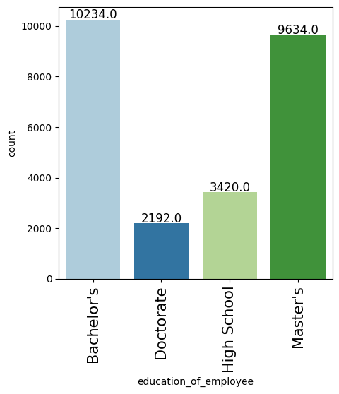

```python
labeled_barplot(data,"education_of_employee")
```

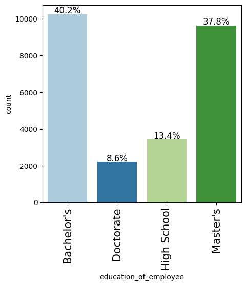

```python
labeled_barplot(data,"education_of_employee", perc=True)
```

- There are four education levels: High School, Bacherlor's, Master's and Doctorate.
- Most of the applications have applicants with Bachelor's degree (10234 - 40.2%), followed closely by Master's degree (9634 - 37.8%), high school (3420 - 13.4%) and lastly doctorate (2192 - 8.6%).

#### Observations on region of employment

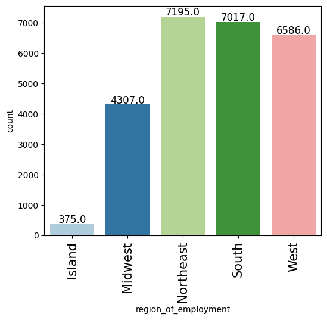

```python
labeled_barplot(data,"region_of_employment")
```

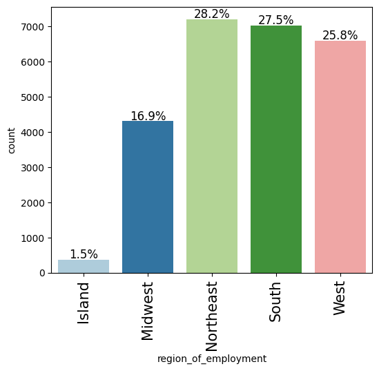

```python
labeled_barplot(data,"region_of_employment", perc=True)
```

- There are 5 different regions of employment: Island, Midwest, Norteast, South and West.
- Regarding the intended region of employment of the applicants, Northeast, South and West have similar number of applicants (Northeast: 7195 - 28.2%, South 7017 - 27.5%, West 6586 - 25.8%), these numbers are followed by MidWest with 4307 - 16.9% applications and lastly Island region with just 375 - 1.5% applications.

#### Observations on job experience

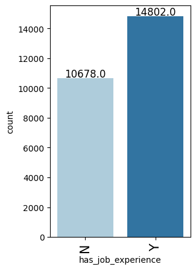

```python
labeled_barplot(data,"has_job_experience")
```

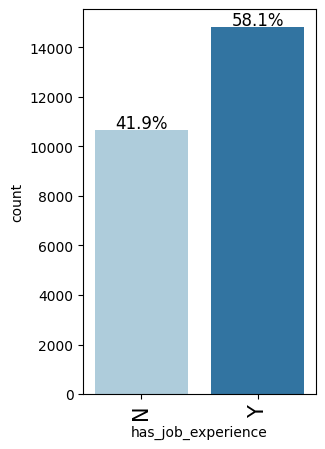

```python
labeled_barplot(data,"has_job_experience", perc=True)
```

- Over 50% of the applicants have job experience totaling 14802(58.1%) and 10678(41.9%) don't have job experience.

#### Observations on continent

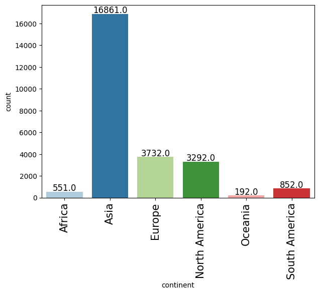

```python
labeled_barplot(data,"continent")
```

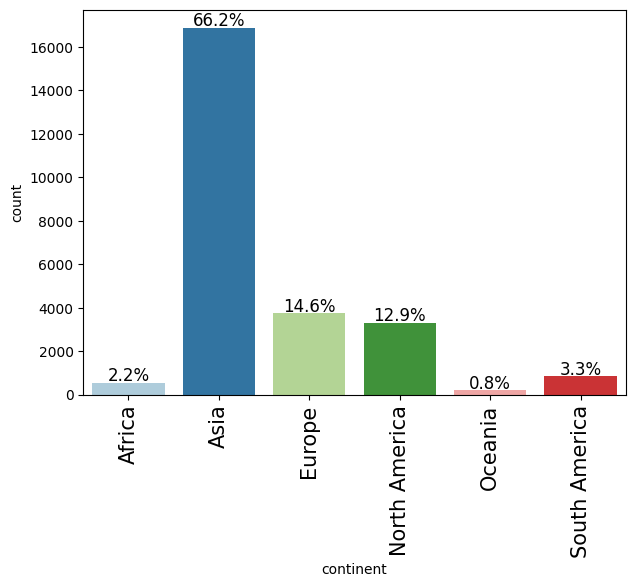

```python
labeled_barplot(data,"continent", perc=True)
```

- There are 6 continents: Africa, Asia, Europe, Nort America, Oceania, South America.
- Most applications are coming from Asia (16861 - 66.2%) and the less amount of applications are coming from Oceania (192 - 0.8%). After Asia, who follows in the ranking is Europe with 3732 (14.6%) applications, closely follow by Nort America with 3292(12.9%) applications, then South America with 852(3.3%) and finally Africa 551(2.2%) and Oceania with 192 (0.8%) applications.

#### Observations on unit of wage

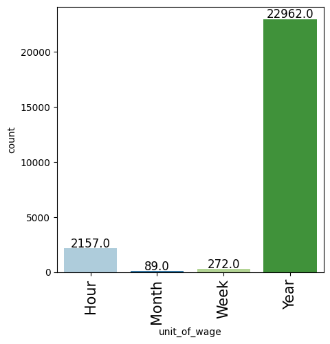

```python
labeled_barplot(data,"unit_of_wage")
```

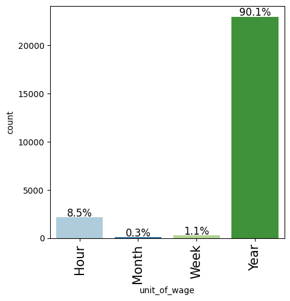

```python
labeled_barplot(data,"unit_of_wage", perc=True)
```

- There are 4 different unit of wage: Hour, Month, Week and Year.
- Around 90% of the applications has unit of wage as year with 22962 (90.1%) applications. These number is follow by the hour unit of wage with 2157 (8.5%) applications and lastly Week and Month are among the less number of applications with week unit of wage for 272(1.1%) applications and month unit of wage with only 89(0.3%) applications.

#### Observations on required job training

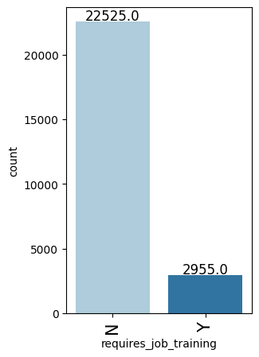

```python
labeled_barplot(data,"requires_job_training")
```

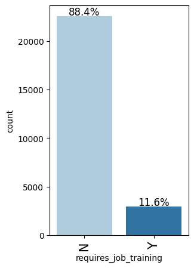

```python
labeled_barplot(data,"requires_job_training", perc=True)
```

- Over 85% of the candidates don't require job training (22525 - 88.4%) and just 2955 (11.6%) do required job training.

#### Observations on full time vs part time position

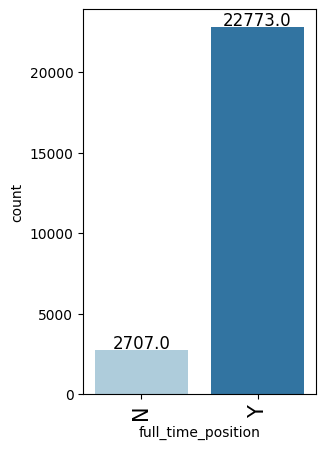

```python
labeled_barplot(data,"full_time_position")
```

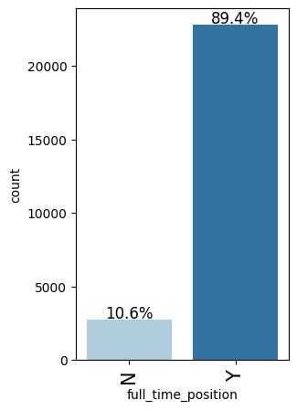

```python
labeled_barplot(data,"full_time_position", perc=True)
```

- Almost 90% of the applications are for full time positions totaling 22773 (89.4%) and just 2707(10.6%) are for part time positions.

#### Observations of prevailing wage

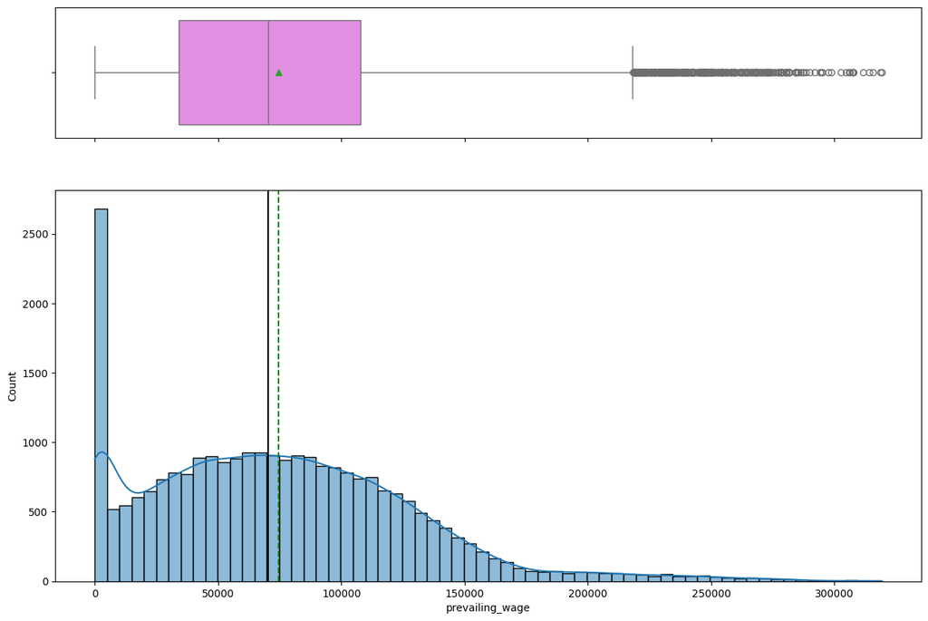

```python
histogram_boxplot(data,"prevailing_wage",kde=True)
```

- As we can see the distribution is right skewed and it has outliers. We will review them later in the process.

#### Observations on number of employees in the employer's company

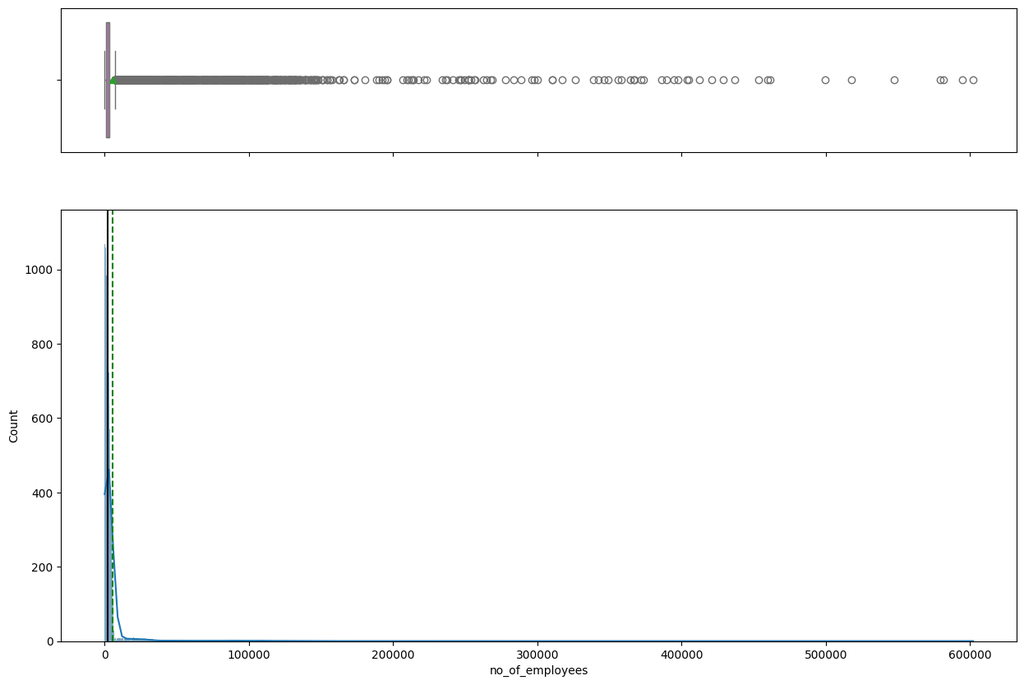

```python
histogram_boxplot(data,"no_of_employees",kde=True)
```

- The number of employees for the companies varied a lot, the distribution is right skewed and it has many outliers.

#### Observations on year in which the employer's company was established

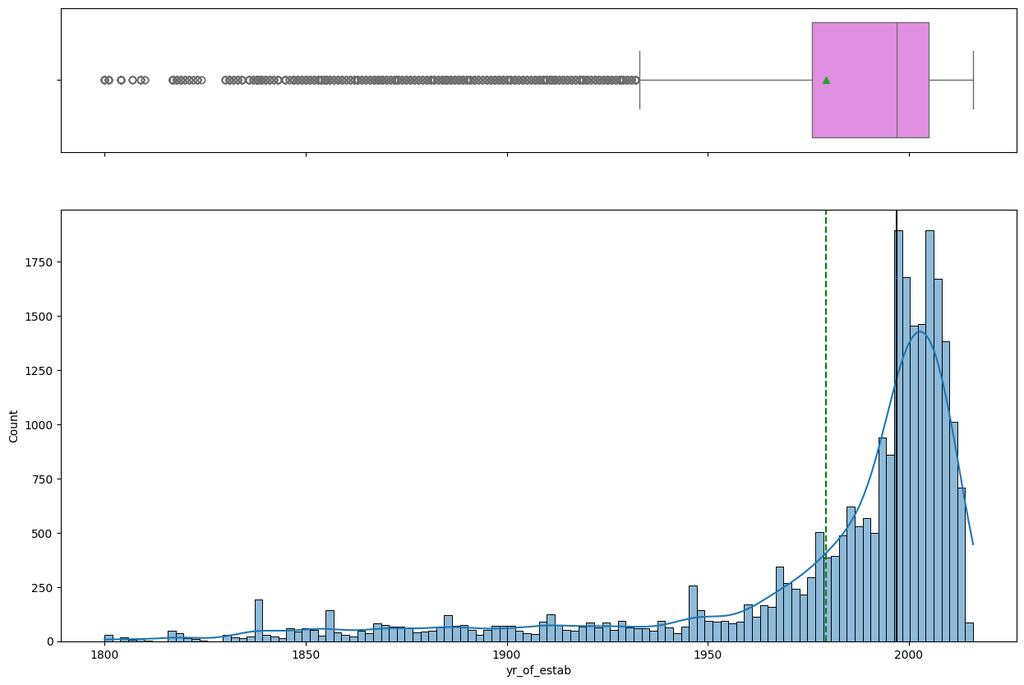

```python
histogram_boxplot(data,"yr_of_estab",kde=True)
```

- The distributIon is left skewed with many outliers and the oldest company was estabish in 1800 and the latest one was establish in 2016 as per the statistical summary.

#### Observations on case status

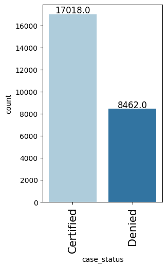

```python
labeled_barplot(data,"case_status")
```

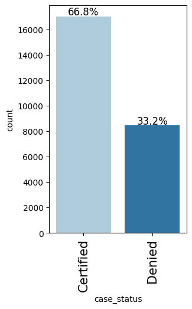

```python
labeled_barplot(data,"case_status", perc=True)
```

- In terms of the case status we can already see that the Certified cases are more than the double of Denied Cases and this shows the dataset is imbalanced. There are 17018 (66.8%) applications that were Certified and only 8462 (33.2%) that were Denied. This denotes a very imbalance class for the target value

### Bivariate Analysis

**Creating functions that will help us with further analysis.**

```python
### function to plot distributions wrt target

def distribution_plot_wrt_target(data, predictor, target):

    fig, axs = plt.subplots(2, 2, figsize=(16, 12))

    target_uniq = data[target].unique()

    axs[0, 0].set_title("Distribution of target for target=" + str(target_uniq[0]))
    sns.histplot(
        data=data[data[target] == target_uniq[0]],
        x=predictor,
        kde=True,
        ax=axs[0, 0],
        color="teal",
        stat="density",
    )

    axs[0, 1].set_title("Distribution of target for target=" + str(target_uniq[1]))
    sns.histplot(
        data=data[data[target] == target_uniq[1]],
        x=predictor,
        kde=True,
        ax=axs[0, 1],
        color="orange",
        stat="density",
    )

    axs[1, 0].set_title("Boxplot w.r.t target")
    sns.boxplot(data=data, x=target, y=predictor, ax=axs[1, 0], palette="gist_rainbow")

    axs[1, 1].set_title("Boxplot (without outliers) w.r.t target")
    sns.boxplot(
        data=data,
        x=target,
        y=predictor,
        ax=axs[1, 1],
        showfliers=False,
        palette="gist_rainbow",
    )

    plt.tight_layout()
    plt.show()
```

```python
def distribution_plot_wrt_target2(data, predictor, target):
    target_uniq = data[target].unique()
    n = len(target_uniq)

    # Create enough subplots for all target values (2 per row)
    ncols = 2
    nrows = (n + 1) // ncols
    fig, axs = plt.subplots(nrows, ncols, figsize=(16, 5 * nrows))
    axs = axs.flatten()  # make it 1D for easier indexing

    # Plot distributions for each target value
    for i, tval in enumerate(target_uniq):
        axs[i].set_title(f"Distribution of {predictor} for target={tval}")
        sns.histplot(
            data=data[data[target] == tval],
            x=predictor,
            kde=True,
            ax=axs[i],
            stat="density"
        )

    # Add boxplots at the end
    box_ax = axs[n] if n < len(axs) else None
    if box_ax:
        box_ax.set_title("Boxplot w.r.t target")
        sns.boxplot(data=data, x=target, y=predictor, ax=box_ax, palette="gist_rainbow")

    if n + 1 < len(axs):
        box_ax2 = axs[n + 1]
        box_ax2.set_title("Boxplot (without outliers) w.r.t target")
        sns.boxplot(
            data=data,
            x=target,
            y=predictor,
            ax=box_ax2,
            showfliers=False,
            palette="gist_rainbow"
        )

    plt.tight_layout()
    plt.show()
```

```python
def stacked_barplot(data, predictor, target):
    """
    Print the category counts and plot a stacked bar chart

    data: dataframe
    predictor: independent variable
    target: target variable
    """
    count = data[predictor].nunique()
    sorter = data[target].value_counts().index[-1]
    tab1 = pd.crosstab(data[predictor], data[target], margins=True).sort_values(
        by=sorter, ascending=False
    )
    print(tab1)
    print("-" * 120)
    tab = pd.crosstab(data[predictor], data[target], normalize="index").sort_values(
        by=sorter, ascending=False
    )
    tab.plot(kind="bar", stacked=True, figsize=(count + 5, 5))
    plt.legend(
        loc="lower left", frameon=False,
    )
    plt.legend(loc="upper left", bbox_to_anchor=(1, 1))
    plt.show()
```

#### Does higher education increase the chances of visa certification for well-paid jobs abroad?

- The fields that need to be involved in this analysis are education_of_employee, case_status and prevailing_wage
- I will filter the data frame by well-paid jobs assuming that those rows that are over 75% are well-paid jobs.
- Then I will analyze the distribution by education and case_status.

```python
# Establish the treshold as the top 25% of rows with the highest wages

threshold=data["prevailing_wage"].quantile(0.75)

# print the value of the treshold
print("The threshold for this analysis is",threshold)

# filter the dataset by that treshhold

well_paid_data=data[data["prevailing_wage"]>threshold]

# assign the columns needed for the analysis to make it more clear

well_paid_data=well_paid_data[["education_of_employee","case_status"]]
```

```
The threshold for this analysis is 107735.51250000001
```

```python
# group by the new dataset by education and case status

well_paid_data.groupby(['education_of_employee', 'case_status']).value_counts()
```

```
education_of_employee  case_status
Bachelor's             Certified      1614
                       Denied          867
Doctorate              Certified       338
                       Denied           54
High School            Certified       292
                       Denied          537
Master's               Certified      2128
                       Denied          540
dtype: int64
```

```
case_status            Certified  Denied   All
education_of_employee
All                         4372    1998  6370
Bachelor's                  1614     867  2481
Master's                    2128     540  2668
High School                  292     537   829
Doctorate                    338      54   392
------------------------------------------------------------------------------------------------------------------------
```

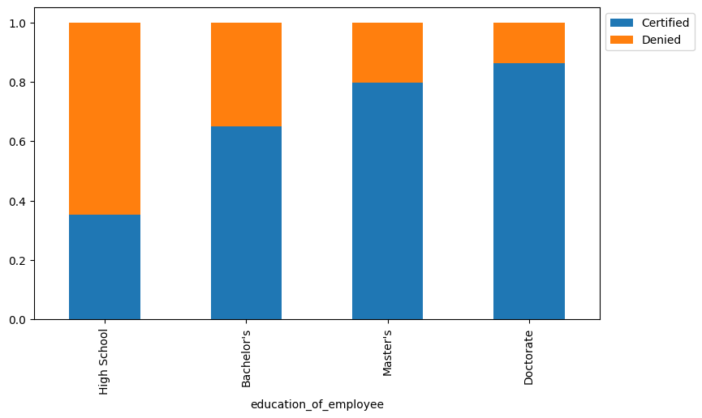

```python
stacked_barplot(well_paid_data,"education_of_employee","case_status")
```

- As we can see in the plot above, the answer to the question is Yes, as education increase in the well-paid jobs there are more posibilities that the visa will be certified (approved). For example, the ratio on certified/denied for High School education has more denied cases than certified cases, this is not true for all the other edudcation levels where there are more certified applications than denied.

#### How does visa status vary across different continents?

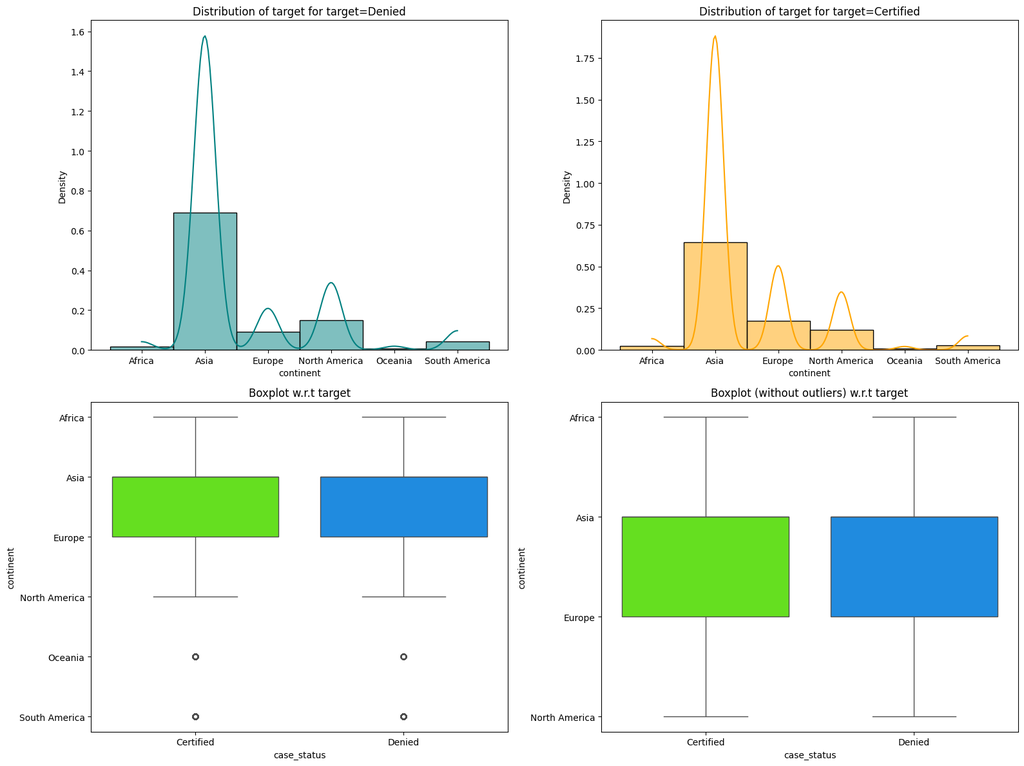

```python
distribution_plot_wrt_target(data,"continent","case_status")
```

```
case_status    Certified  Denied    All
continent
All                17018    8462  25480
Asia               11012    5849  16861
North America       2037    1255   3292
Europe              2957     775   3732
South America        493     359    852
Africa               397     154    551
Oceania              122      70    192
------------------------------------------------------------------------------------------------------------------------
```

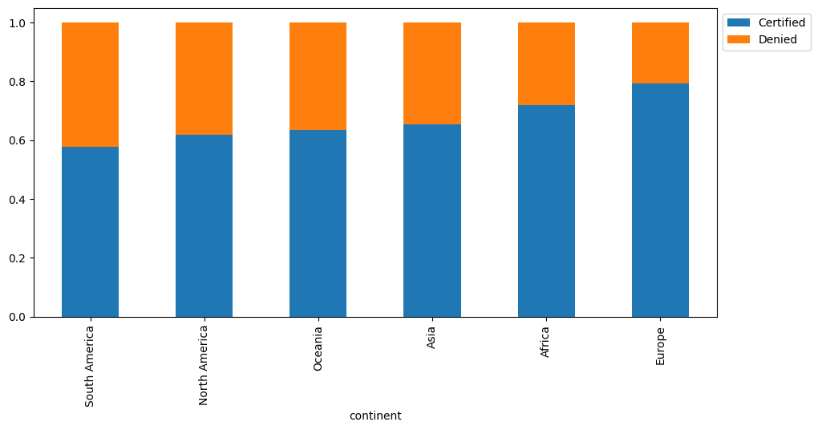

```python
stacked_barplot(data,"continent","case_status")
```

- All countries have more certified visas than denied visas but this might be related just to the imbalance of the dataset noted before. Let's get the percentage of certified vs denied for each country.

```python
df_pivot = data.pivot_table(
    index='continent',
    columns='case_status',
    aggfunc='size',
    fill_value=0
)

df_percent = df_pivot.div(df_pivot.sum(axis=1), axis=0) * 100
print(df_percent)
```

```
case_status    Certified     Denied
continent
Africa         72.050817  27.949183
Asia           65.310480  34.689520
Europe         79.233655  20.766345
North America  61.877278  38.122722
Oceania        63.541667  36.458333
South America  57.863850  42.136150
```

- As we can see in the table above we have Africa with a rate of 72% Certified vs 27% Denied, Asia with 65% Certified vs 34% Denied, Europe with 79% Certified vs 20 % Denied, North America with 61 % Certified vs 38 % Denied, Oceania with 63 % Certified vs 36 % Denied and lastly South America with the lowest Certified rate at 57 % vs 42 % Denied. The continent with the biggest Certified rate is Europe at 79%.

#### Does having prior work experience influence the chances of visa certification for career opportunities abroad?

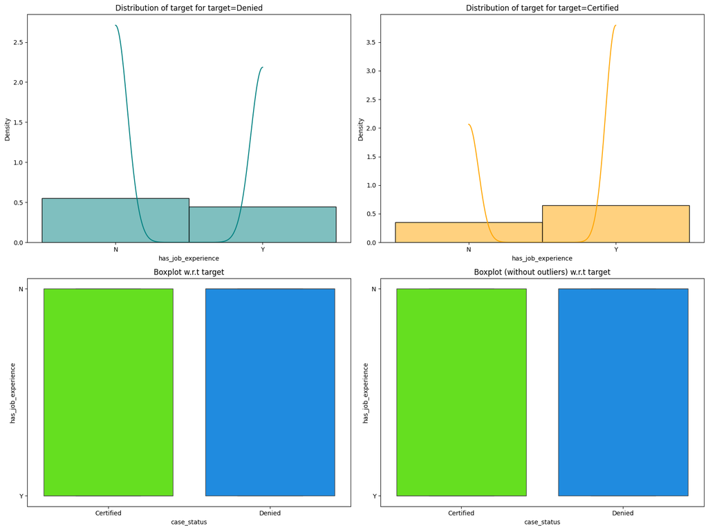

```python
distribution_plot_wrt_target(data,"has_job_experience","case_status")
```

```
case_status         Certified  Denied    All
has_job_experience
All                     17018    8462  25480
N                        5994    4684  10678
Y                       11024    3778  14802
------------------------------------------------------------------------------------------------------------------------
```

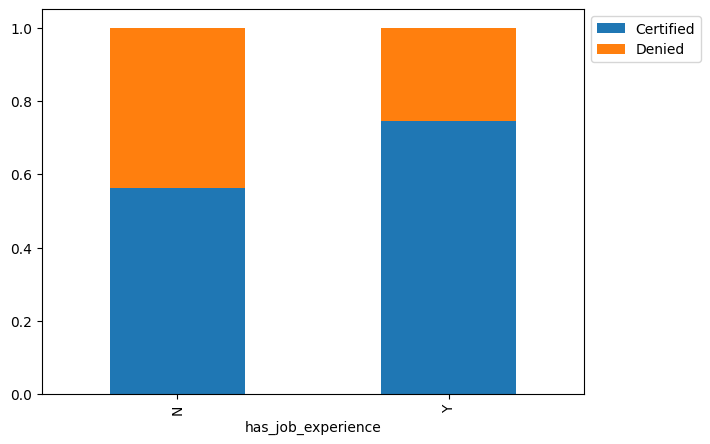

```python
stacked_barplot(data,"has_job_experience","case_status")
```

- Having job experience slightly increase the amount of Certified applications. Let's check the percentages.

```python
df_pivot = data.pivot_table(
    index='has_job_experience',
    columns='case_status',
    aggfunc='size',
    fill_value=0
)

df_percent = df_pivot.div(df_pivot.sum(axis=1), axis=0) * 100
print(df_percent)
```

```
case_status         Certified     Denied
has_job_experience
N                   56.134108  43.865892
Y                   74.476422  25.523578
```

- As we can see not having job experience has a denial rate of 43% while having job experience has a denial rate of only 25%. For certified the difference between 74% certified with job experience, and 56% Certified with no job experience is 18 percentage points. Now if we do the following (74.48 (Certfied with job experience) -56.13 (Certified without job experinece))/56.13 (Certified without job experinece) we can say that applicants with job experience are about 33% more likely to be certified compared to those without experience. The answer to the question is Yes, having prior Job Experience increase the chances of getting the visa.

#### Is the prevailing wage consistent across all regions of the US?

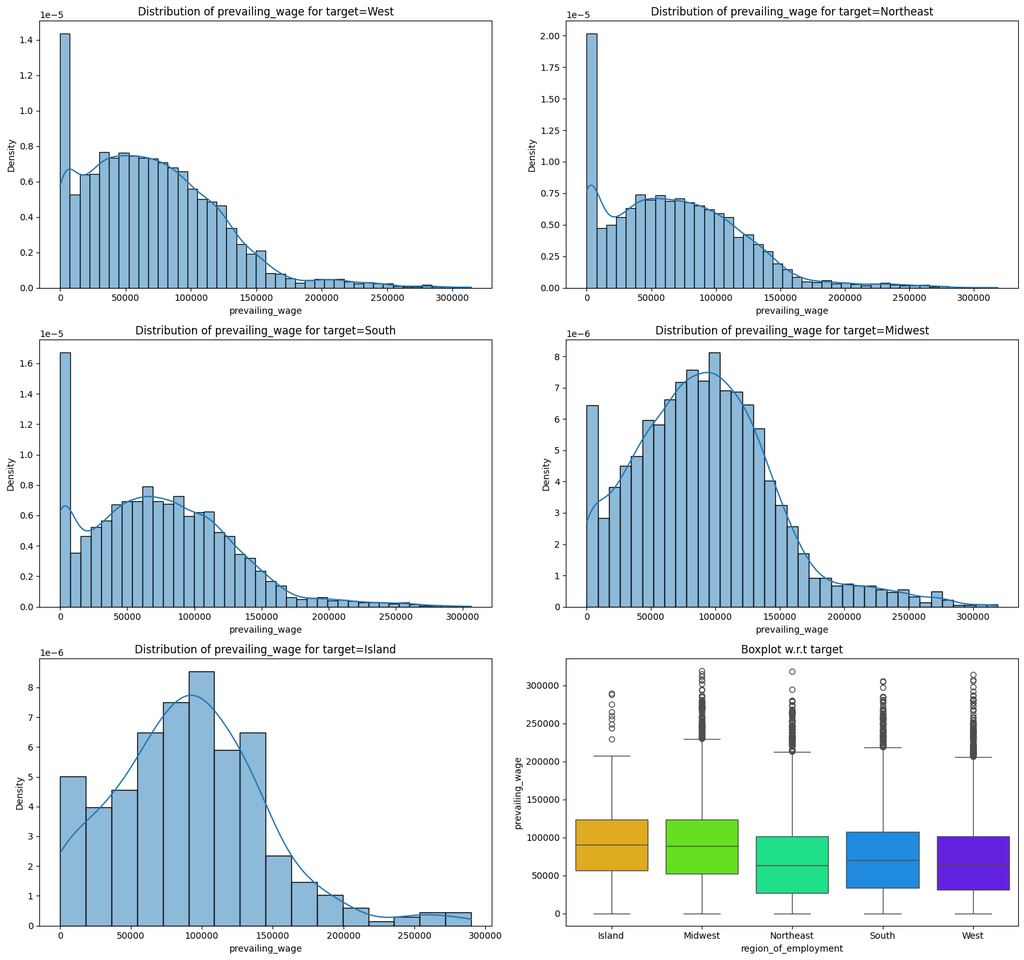

```python
distribution_plot_wrt_target2(data,"prevailing_wage","region_of_employment")
```

#### Does visa status vary with changes in the prevailing wage set to protect both local talent and foreign workers?

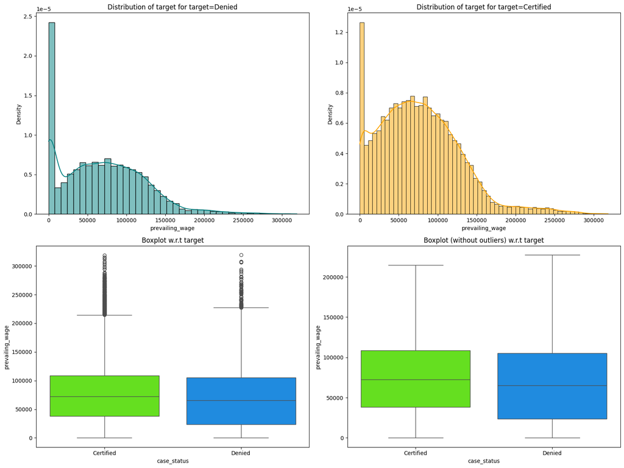

```python
distribution_plot_wrt_target(data,"prevailing_wage","case_status")
```

- The boxplot are very similar with an slightly difference between the Q3 for Certified vs Denied. Taking into account this, I can confidently said that the visa status does not vary much related to the wage. The distribution of the prevailing_wage for Certified and Denied case status is right skewed.

#### Does the unit of prevailing wage (Hourly, Weekly, etc.) have any impact on the likelihood of visa application certification?

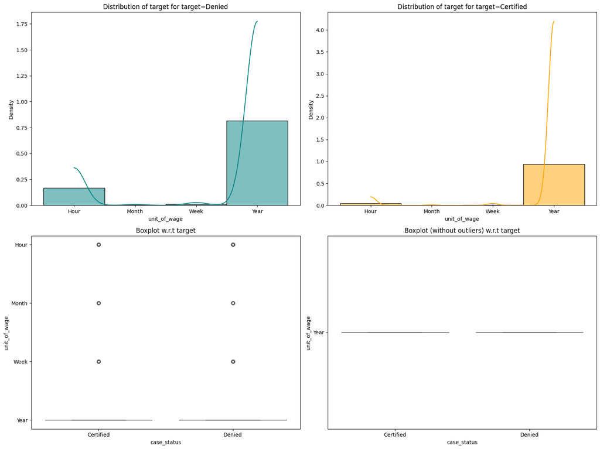

```python
distribution_plot_wrt_target(data,"unit_of_wage","case_status")
```

```
case_status   Certified  Denied    All
unit_of_wage
All               17018    8462  25480
Year              16047    6915  22962
Hour                747    1410   2157
Week                169     103    272
Month                55      34     89
------------------------------------------------------------------------------------------------------------------------
```

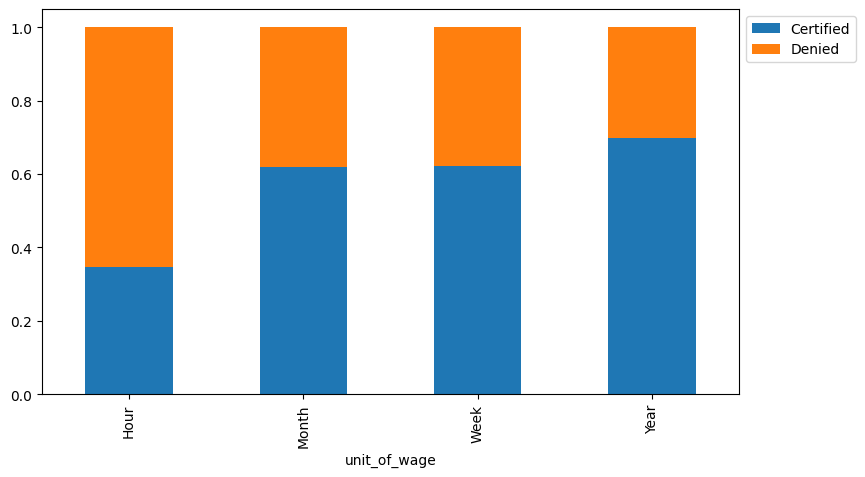

```python
stacked_barplot(data,"unit_of_wage","case_status")
```

## Data Pre-processing

### Define the function to show the outliers for each numeric field.

```python
def showoutliers(column,df):
    # Find the Q1,Q3,IQR and Lower and upper whiskers of the boxplot below
    Q1 = column.quantile(0.25)
    Q3 = column.quantile(0.75)

    IQR = Q3 - Q1                   #Inter Quantile Range (75th percentile - 25th percentile)

    lower_whisker = Q1 - 1.5*IQR    #Finding lower and upper bounds for all values.
    upper_whisker = Q3 + 1.5*IQR

    #Print all the values to include in the analysis.
    print("Lower Whisker: ",lower_whisker)
    print("Upper Whisker: ",upper_whisker)
    print("IQR: ",IQR)
    print("Q1: ",Q1)
    print("Q3: ",Q3)

    records_below=df[column<=lower_whisker].value_counts()
    print("The amount of outliers below the lower_whisker is:", records_below.count())
    records_above=df[column>=upper_whisker].value_counts()
    print("The amount of outliers above the upper_whisker is: ",records_above.count())

    if records_below.count()!=0:
        percentage=records_below.count()/df.shape[0]*100
        print("The records below the lower whisker represent ",percentage,"%","and below we have the first and last 10 rows")
        print(records_below.head(10))
        print (records_below.tail(10))
    if records_above.count()!=0:
        percentage=records_above.count()/df.shape[0]*100
        print("The records above the upper whisker represent ",percentage,"%","and below we have the first and last 10 rows")
        print (records_above.head(10))
        print (records_above.tail(10))
```

### Outlier Check

```
Lower Whisker:  -76564.56875000002
Upper Whisker:  218315.56125000003
IQR:  73720.03250000002
Q1:  34015.479999999996
Q3:  107735.51250000001
The amount of outliers below the lower_whisker is: 0
The amount of outliers above the upper_whisker is:  427
The records above the upper whisker represent  1.6758241758241759 % and below we have the first and last 10 rows
case_id    continent      education_of_employee  has_job_experience  requires_job_training  no_of_employees  yr_of_estab  region_of_employment  prevailing_wage  unit_of_wage  full_time_position  case_status
EZYV10151  Asia           Bachelor's             Y                   N                      3525             1970         Island                289878.68        Year          Y                   Denied         1
EZYV326    North America  Bachelor's             Y                   N                      629              2004         West                  232227.33        Year          Y                   Certified      1
EZYV3190   Asia           Master's               Y                   N                      2490             1970         West                  276894.08        Year          N                   Certified      1
EZYV3138   Asia           Doctorate              N                   Y                      61396            1987         Midwest               242406.32        Year          Y                   Denied         1
EZYV2991   Asia           Master's               N                   N                      201              2006         Midwest               222221.67        Year          Y                   Denied         1
EZYV2862   Asia           Master's               N                   N                      1873             1843         Midwest               267868.56        Year          Y                   Denied         1
EZYV2767   Asia           Master's               Y                   N                      1999             1971         Northeast             264760.64        Year          Y                   Certified      1
EZYV2719   Asia           Doctorate              Y                   N                      2560             1997         West                  230916.64        Year          Y                   Certified      1
EZYV2612   Asia           Bachelor's             N                   N                      3174             2005         Northeast             263877.21        Year          Y                   Denied         1
EZYV2555   North America  Bachelor's             Y                   N                      721              2014         Northeast             262852.71        Year          Y                   Certified      1
dtype: int64
case_id    continent      education_of_employee  has_job_experience  requires_job_training  no_of_employees  yr_of_estab  region_of_employment  prevailing_wage  unit_of_wage  full_time_position  case_status
EZYV17911  North America  Master's               N                   N                      1242             1987         Midwest               287433.90        Year          Y                   Certified      1
EZYV17791  Asia           Bachelor's             N                   N                      3443             1987         West                  226169.32        Year          Y                   Denied         1
EZYV17705  Asia           Bachelor's             Y                   N                      3193             1998         Northeast             221595.07        Year          N                   Denied         1
EZYV17626  Asia           Master's               N                   N                      12590            1998         South                 297589.88        Year          Y                   Certified      1
EZYV17595  Asia           Master's               N                   N                      1115             1999         Midwest               281344.22        Year          Y                   Certified      1
EZYV17569  North America  Master's               N                   N                      1380             1998         South                 254015.02        Year          N                   Certified      1
EZYV17563  Asia           Bachelor's             Y                   N                      1531             2004         Northeast             221524.92        Year          Y                   Certified      1
EZYV17551  North America  Doctorate              Y                   Y                      4464             1984         Northeast             239224.53        Year          Y                   Certified      1
EZYV17536  Asia           High School            N                   N                      1443             2004         South                 257775.44        Year          Y                   Certified      1
EZYV9898   Asia           High School            Y                   N                      18               2001         West                  272311.21        Year          Y                   Denied         1
dtype: int64
```

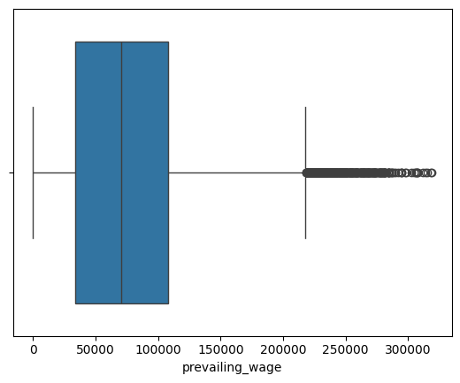

```python
sns.boxplot(data=data,x="prevailing_wage")
showoutliers(data["prevailing_wage"],data)
```

- The distribution is right skewed.
- The amount of outliers below the lower_whisker is: 0
- The amount of outliers above the upper_whisker is: 427
- The records above the upper whisker represent 1.6758241758241759 %
- The head and tail records for the outliers shows that the unit_of_wage is year.
- We can see in the graphic that the outliers are greater than 218315 and possibly less than 400000 dollars a year, therefore they look like possible values.
- After analyzing the outliers head and tail records for prevailing_wage I have decided that I won't treat them because they are real numbers considering the unit_of_wage for these salaries are year (according to the head and tail of the records) and the percentage of these outliers is less than 2% of the whole dataset (1.67% equivalent to 427 records).

```
Lower Whisker:  1932.5
Upper Whisker:  2048.5
IQR:  29.0
Q1:  1976.0
Q3:  2005.0
The amount of outliers below the lower_whisker is: 3260
The amount of outliers above the upper_whisker is:  0
The records below the lower whisker represent  12.794348508634224 % and below we have the first and last 10 rows
case_id    continent  education_of_employee  has_job_experience  requires_job_training  no_of_employees  yr_of_estab  region_of_employment  prevailing_wage  unit_of_wage  full_time_position  case_status
EZYV04     Asia       Bachelor's             N                   N                      98               1897         West                  83434.0300       Year          Y                   Denied         1
EZYV25424  Asia       Master's               Y                   N                      4017             1848         South                 72947.5000       Year          N                   Certified      1
EZYV2534   Europe     Master's               Y                   N                      1101             1850         West                  212371.5900      Year          Y                   Certified      1
EZYV25344  Asia       Master's               Y                   N                      53376            1875         South                 58641.8900       Year          Y                   Certified      1
EZYV25354  Asia       Master's               Y                   N                      2414             1887         South                 43380.4000       Year          Y                   Certified      1
EZYV2536   Europe     Master's               N                   N                      4647             1899         Northeast             34639.6500       Year          Y                   Certified      1
EZYV25368  Europe     High School            N                   Y                      18               1831         South                 125704.6800      Year          Y                   Certified      1
EZYV25387  Asia       Doctorate              N                   N                      2509             1849         West                  491.5601         Hour          Y                   Certified      1
EZYV25391  Asia       Bachelor's             Y                   N                      1203             1873         Midwest               143.4372         Hour          Y                   Denied         1
EZYV2541   Asia       Master's               Y                   N                      3460             1898         Northeast             64158.9800       Year          Y                   Certified      1
dtype: int64
case_id    continent      education_of_employee  has_job_experience  requires_job_training  no_of_employees  yr_of_estab  region_of_employment  prevailing_wage  unit_of_wage  full_time_position  case_status
EZYV17474  Asia           Bachelor's             Y                   N                      2453             1885         West                  101203.030       Year          Y                   Certified      1
EZYV17475  Asia           Bachelor's             Y                   N                      764              1908         Midwest               46064.580        Year          Y                   Certified      1
EZYV17482  Asia           Bachelor's             Y                   N                      1204             1863         South                 55394.400        Year          N                   Certified      1
EZYV17483  Africa         Doctorate              N                   N                      1785             1905         West                  93108.080        Year          Y                   Certified      1
EZYV17487  Europe         Doctorate              N                   N                      3175             1913         West                  86969.680        Year          Y                   Certified      1
EZYV1749   Asia           Master's               Y                   N                      1690             1823         South                 23753.010        Year          Y                   Certified      1
EZYV17492  Europe         Master's               N                   N                      2500             1915         West                  49424.430        Year          N                   Certified      1
EZYV17494  North America  Bachelor's             Y                   N                      284              1909         West                  154163.540       Year          Y                   Denied         1
EZYV17495  Asia           Master's               Y                   N                      5421             1884         South                 527.097          Hour          Y                   Denied         1
EZYV9998   Asia           Bachelor's             Y                   N                      1273             1923         Northeast             46124.790        Year          Y                   Denied         1
dtype: int64
```

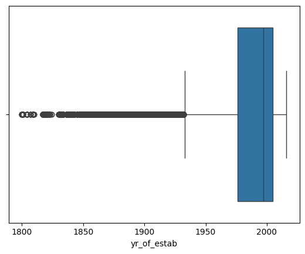

```python
sns.boxplot(data=data,x="yr_of_estab")
showoutliers(data["yr_of_estab"],data)
```

- The distribution is left skewed.
- The amount of outliers below the lower_whisker is: 3260
- The amount of outliers above the upper_whisker is: 0
- The records below the lower whisker represent 12.794348508634224 %
- We have companies that were establish in the 1800's which is in the realm of possibility for that field.
- There is no more information in the dataset to confirm if these years are correct or not.
- The anomalies don't need to be treated given the values are not out of the realm of posibility for the funding year of a company and they only represent 12% of the dataset.

```
Lower Whisker:  -2701.0
Upper Whisker:  7227.0
IQR:  2482.0
Q1:  1022.0
Q3:  3504.0
The amount of outliers below the lower_whisker is: 0
The amount of outliers above the upper_whisker is:  1556
The records above the upper whisker represent  6.106750392464678 % and below we have the first and last 10 rows
case_id    continent      education_of_employee  has_job_experience  requires_job_training  no_of_employees  yr_of_estab  region_of_employment  prevailing_wage  unit_of_wage  full_time_position  case_status
EZYV01     Asia           High School            N                   N                      14513            2007         West                  592.2029         Hour          Y                   Denied         1
EZYV25038  Africa         Master's               Y                   N                      123482           1992         Northeast             92305.7900       Year          Y                   Certified      1
EZYV25350  Asia           High School            Y                   N                      89016            1965         South                 223.0344         Hour          Y                   Certified      1
EZYV25344  Asia           Master's               Y                   N                      53376            1875         South                 58641.8900       Year          Y                   Certified      1
EZYV25325  Europe         High School            Y                   N                      20826            1968         West                  122162.4300      Year          Y                   Certified      1
EZYV25309  North America  Master's               N                   N                      82953            1977         Northeast             42.7705          Hour          Y                   Denied         1
EZYV25298  Asia           Master's               Y                   N                      28730            1979         Northeast             76465.4000       Year          Y                   Certified      1
EZYV25284  Asia           Master's               N                   N                      10762            2005         West                  110106.1900      Year          N                   Denied         1
EZYV25274  Asia           Master's               Y                   N                      138563           2010         West                  60914.3800       Year          Y                   Certified      1
EZYV25241  Europe         Bachelor's             N                   Y                      72173            1919         South                 85135.2700       Year          Y                   Certified      1
dtype: int64
case_id    continent      education_of_employee  has_job_experience  requires_job_training  no_of_employees  yr_of_estab  region_of_employment  prevailing_wage  unit_of_wage  full_time_position  case_status
EZYV17578  North America  Bachelor's             Y                   N                      81392            2010         South                 86051.49         Year          Y                   Certified      1
EZYV17571  Asia           Master's               Y                   N                      12769            2009         West                  46620.20         Year          Y                   Certified      1
EZYV17546  Asia           Bachelor's             N                   N                      24518            1962         West                  103394.96        Year          Y                   Certified      1
EZYV17535  Europe         Doctorate              Y                   N                      35719            2013         West                  1075.92          Year          Y                   Certified      1
EZYV17534  Europe         Bachelor's             N                   N                      13510            1836         Northeast             53745.53         Year          Y                   Certified      1
EZYV17529  Europe         Doctorate              Y                   N                      373353           1977         South                 28248.56         Year          Y                   Certified      1
EZYV17516  Europe         Master's               N                   N                      57288            1981         West                  33910.58         Year          Y                   Certified      1
EZYV17505  Asia           Master's               Y                   N                      27959            2004         West                  138437.36        Year          Y                   Certified      1
EZYV17461  Europe         Master's               N                   N                      70615            1973         West                  7834.50          Year          Y                   Certified      1
EZYV9997   Asia           Bachelor's             N                   N                      16220            1994         Midwest               86889.87         Year          Y                   Certified      1
dtype: int64
```

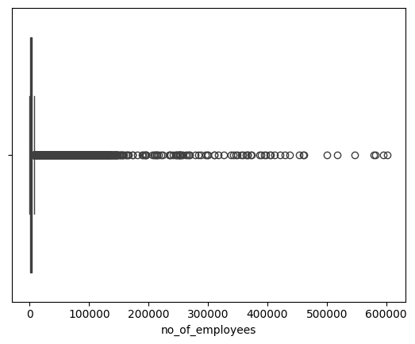

```python
sns.boxplot(data=data,x="no_of_employees")
showoutliers(data["no_of_employees"],data)
```

- The distribution is right skewed.
- The amount of outliers below the lower_whisker is: 0
- The amount of outliers above the upper_whisker is: 1556
- The records above the upper whisker represent 6.106750392464678 %
- There is not enough information to confirm that the data is accurate, the outliers represent only 6% of the dataset and the negative values were converted to absolutes so for all this reasons I won't treat the outliers for this field.

### Missing Values

```python
data.isnull().sum()
```

```
case_id                  0
continent                0
education_of_employee    0
has_job_experience       0
requires_job_training    0
no_of_employees          0
yr_of_estab              0
region_of_employment     0
prevailing_wage          0
unit_of_wage             0
full_time_position       0
case_status              0
dtype: int64
```

- There are no missing values in the dataset

### Duplicates

```python
data.duplicated().sum()
```

```
0
```

- There are no duplicated values in the dataset

### Feature Engineering

```python
data.info()
```

```
<class 'pandas.core.frame.DataFrame'>
RangeIndex: 25480 entries, 0 to 25479
Data columns (total 12 columns):
 #   Column                 Non-Null Count  Dtype
---  ------                 --------------  -----
 0   case_id                25480 non-null  category
 1   continent              25480 non-null  category
 2   education_of_employee  25480 non-null  category
 3   has_job_experience     25480 non-null  category
 4   requires_job_training  25480 non-null  category
 5   no_of_employees        25480 non-null  int64
 6   yr_of_estab            25480 non-null  int64
 7   region_of_employment   25480 non-null  category
 8   prevailing_wage        25480 non-null  float64
 9   unit_of_wage           25480 non-null  category
 10  full_time_position     25480 non-null  category
 11  case_status            25480 non-null  category
dtypes: category(9), float64(1), int64(2)
memory usage: 2.0 MB
```

- All the object columns were converted to category already.

### Data Preparation for modeling

- In order to prepare the data, all categorical variables need to be converted

```python
# For Case Status we can replace Certified with 1 and Denied with 0
data["case_status"] = data["case_status"].replace({"Certified": 1, "Denied": 0})

# drop the target value from the dataframe case_status and the case_id given that is an identifier that is not needed for the analysis

X = data.drop(["case_status","case_id"],axis=1)
y = data["case_status"]

# get dummies for the rest of the columns in X
X = pd.get_dummies(X,drop_first=True)

# check the first 5 rows of the dataset
print(X.head())

# check the new shape of the dataset
print(X.shape)
```

```
   no_of_employees  yr_of_estab  prevailing_wage  continent_Asia  \
0            14513         2007         592.2029               1
1             2412         2002       83425.6500               1
2            44444         2008      122996.8600               1
3               98         1897       83434.0300               1
4             1082         2005      149907.3900               0

   continent_Europe  continent_North America  continent_Oceania  \
0                 0                        0                  0
1                 0                        0                  0
2                 0                        0                  0
3                 0                        0                  0
4                 0                        0                  0

   continent_South America  education_of_employee_Doctorate  \
```

[output cut: 43 more lines]

```python
# check the new columns of the dataset
X.info()
```

```
<class 'pandas.core.frame.DataFrame'>
RangeIndex: 25480 entries, 0 to 25479
Data columns (total 21 columns):
 #   Column                             Non-Null Count  Dtype
---  ------                             --------------  -----
 0   no_of_employees                    25480 non-null  int64
 1   yr_of_estab                        25480 non-null  int64
 2   prevailing_wage                    25480 non-null  float64
 3   continent_Asia                     25480 non-null  uint8
 4   continent_Europe                   25480 non-null  uint8
 5   continent_North America            25480 non-null  uint8
 6   continent_Oceania                  25480 non-null  uint8
 7   continent_South America            25480 non-null  uint8
 8   education_of_employee_Doctorate    25480 non-null  uint8
 9   education_of_employee_High School  25480 non-null  uint8
 10  education_of_employee_Master's     25480 non-null  uint8
 11  has_job_experience_Y               25480 non-null  uint8
 12  requires_job_training_Y            25480 non-null  uint8
 13  region_of_employment_Midwest       25480 non-null  uint8
 14  region_of_employment_Northeast     25480 non-null  uint8
 15  region_of_employment_South         25480 non-null  uint8
 16  region_of_employment_West          25480 non-null  uint8
 17  unit_of_wage_Month                 25480 non-null  uint8
 18  unit_of_wage_Week                  25480 non-null  uint8
 19  unit_of_wage_Year                  25480 non-null  uint8
 20  full_time_position_Y               25480 non-null  uint8
dtypes: float64(1), int64(2), uint8(18)
memory usage: 1.0 MB
```

```python
# check the head of X
X.head()
```

|  | no_of_employees | yr_of_estab | prevailing_wage | continent_Asia | continent_Europe | continent_North America | continent_Oceania | continent_South America | education_of_employee_Doctorate | education_of_employee_High School | ... | has_job_experience_Y | requires_job_training_Y | region_of_employment_Midwest | region_of_employment_Northeast | region_of_employment_South | region_of_employment_West | unit_of_wage_Month | unit_of_wage_Week | unit_of_wage_Year | full_time_position_Y |
| --- | --- | --- | --- | --- | --- | --- | --- | --- | --- | --- | --- | --- | --- | --- | --- | --- | --- | --- | --- | --- | --- |
| 0 | 14513 | 2007 | 592.2029 | 1 | 0 | 0 | 0 | 0 | 0 | 1 | ... | 0 | 0 | 0 | 0 | 0 | 1 | 0 | 0 | 0 | 1 |
| 1 | 2412 | 2002 | 83425.6500 | 1 | 0 | 0 | 0 | 0 | 0 | 0 | ... | 1 | 0 | 0 | 1 | 0 | 0 | 0 | 0 | 1 | 1 |
| 2 | 44444 | 2008 | 122996.8600 | 1 | 0 | 0 | 0 | 0 | 0 | 0 | ... | 0 | 1 | 0 | 0 | 0 | 1 | 0 | 0 | 1 | 1 |
| 3 | 98 | 1897 | 83434.0300 | 1 | 0 | 0 | 0 | 0 | 0 | 0 | ... | 0 | 0 | 0 | 0 | 0 | 1 | 0 | 0 | 1 | 1 |
| 4 | 1082 | 2005 | 149907.3900 | 0 | 0 | 0 | 0 | 0 | 0 | 0 | ... | 1 | 0 | 0 | 0 | 1 | 0 | 0 | 0 | 1 | 1 |

5 rows × 21 columns

- All categorical variables have been converted to numeric.
- The X dataframe contains 25480 rows and 21 columns.

## Model Building

### Model Evaluation Criterion

- Choose the primary metric to evaluate the model on: The primary metric choosen is Precision.
- Elaborate on the rationale behind choosing the metric:
- What is the objective?
- Facilitate the process of visa approvals.
- Recommend a suitable profile for the applicants for whom the visa should be certified or denied based on the drivers that significantly influence the case status.

What will cost more to the company? Rejecting a deserving applicant or approving a non-deserving applicant?

- The cost of falsely approving an unqualified visa is high given a visa allows an individual to move to US and work and live in the country, therefore , Precision becomes critical (High precision = fewer false approvals) and it's the primary metric for model performance.

First, let's create functions to calculate different metrics and confusion matrix so that we don't have to use the same code repeatedly for each model.

- The `model_performance_classification_sklearn` function will be used to check the model performance of models.
- The `confusion_matrix_sklearn` function will be used to plot the confusion matrix.

### Functions for the models

```python
# defining a function to compute different metrics to check performance of a classification model built using sklearn

def model_performance_classification_sklearn(model, predictors, target):
    """
    Function to compute different metrics to check classification model performance

    model: classifier
    predictors: independent variables
    target: dependent variable
    """

    # predicting using the independent variables
    pred = model.predict(predictors)

    acc = accuracy_score(target, pred)  # to compute Accuracy
    recall = recall_score(target, pred)  # to compute Recall
    precision = precision_score(target, pred)  # to compute Precision
    f1 = f1_score(target, pred)  # to compute F1-score

    # creating a dataframe of metrics
    df_perf = pd.DataFrame(
        {"Accuracy": acc, "Recall": recall, "Precision": precision, "F1": f1,},
        index=[0],
    )

    return df_perf
```

```python
def confusion_matrix_sklearn(model, predictors, target):
    """
    To plot the confusion_matrix with percentages

    model: classifier
    predictors: independent variables
    target: dependent variable
    """
    y_pred = model.predict(predictors)
    cm = confusion_matrix(target, y_pred)
    labels = np.asarray(
        [
            ["{0:0.0f}".format(item) + "\n{0:.2%}".format(item / cm.flatten().sum())]
            for item in cm.flatten()
        ]
    ).reshape(2, 2)

    plt.figure(figsize=(6, 4))
    sns.heatmap(cm, annot=labels, fmt="")
    plt.ylabel("True label")
    plt.xlabel("Predicted label")
```

#### Defining scorer to be used for cross-validation and hyperparameter tuning along with the kfold for all models

```python
scorer_value=metrics.make_scorer(metrics.precision_score)

# Defne the kfold for all models
kfold = StratifiedKFold(n_splits=10, shuffle=True, random_state=1)
```

**We are now done with pre-processing and evaluation criterion, so let's start building the model.**

#### Split in training, validation and test

```python
# Splitting data into training, validation and test set:

# first we split data into 2 parts, say train and validation
X_train, X_val, y_train, y_val = train_test_split(
    X, y, test_size=0.3, random_state=1, stratify=y
)

# Then we split validation in validation and test
X_val,X_test,y_val,y_test = train_test_split(
    X_val,y_val,test_size=0.4,random_state=1,stratify=y_val
)

print(X_train.shape, X_val.shape, X_test.shape)
```

```
(17836, 21) (4586, 21) (3058, 21)
```

#### Check class balance for the whole dataset

```python
# Checking class balance for whole data, train set, validation set, and test set

print("Target value ratio in y")
print(y.value_counts(1))
print("*" * 80)
print("Target value ratio in y_train")
print(y_train.value_counts(1))
print("*" * 80)
print("Target value ratio in y_val")
print(y_val.value_counts(1))
print("*" * 80)
print("Target value ratio in y_test")
print(y_test.value_counts(1))
print("*" * 80)
```

```
Target value ratio in y
1    0.667896
0    0.332104
Name: case_status, dtype: float64
Target value ratio in y_train
1    0.667919
0    0.332081
Name: case_status, dtype: float64
Target value ratio in y_val
1    0.667902
0    0.332098
Name: case_status, dtype: float64
Target value ratio in y_test
1    0.667757
0    0.332243
Name: case_status, dtype: float64
```

The percentage of classes between the train, validation and test sets are very similar

### Model building with Original data

#### Decision Tree

```python
results_original_df = []
results_original_df = pd.DataFrame(columns=["model", "mean of cv_score training set","precision validation set"])
```

```python
# Decision Tree Classifier
dtree_original=DecisionTreeClassifier(random_state=1)

# Fit the training set
dtree_original.fit(X_train,y_train)

# Get the cross validation scores
results = cross_val_score(dtree_original, X_train, y_train, cv=kfold, scoring=scorer_value)

# Get the precision for the validation data

precision=precision_score(y_val, dtree_original.predict(X_val))

# Add the mode, the cross validation mean and the precision on the validation set to a dataframe

results_original_df = results_original_df._append({"model": "Decision Classifier ", "mean of cv_score training set": results.mean(),"precision validation set": precision}, ignore_index=True)
```

#### Bagging Classifier

```python
#Bagging Classifier
bagging_original=BaggingClassifier(random_state=1)
#Fit the training set
bagging_original.fit(X_train,y_train)

# Get the cross validation scores
results = cross_val_score(bagging_original, X_train, y_train, cv=kfold, scoring=scorer_value)

# Get the precision for the validation data

precision=precision_score(y_val, bagging_original.predict(X_val))

# Add the mode, the cross validation mean and the precision on the validation set to a dataframe

results_original_df = results_original_df._append({"model": "Bagging Classifier " , "mean of cv_score training set": results.mean(),"precision validation set": precision}, ignore_index=True)
```

#### Random Forest Classifier

```python
#Random Forest Classifier

randomf_original=RandomForestClassifier(random_state=1)
# Fit the training set
randomf_original.fit(X_train,y_train)

# Get the cross validation scores
results = cross_val_score(randomf_original, X_train, y_train, cv=kfold, scoring=scorer_value)

# Get the precision for the validation data

precision=precision_score(y_val, randomf_original.predict(X_val))

# Add the mode, the cross validation mean and the precision on the validation set to a dataframe

results_original_df = results_original_df._append({"model": "Random Forest Classifier", "mean of cv_score training set": results.mean(),"precision validation set": precision}, ignore_index=True)
```

#### Boosting Classifier

```python
#Gradient Boosting Classifier

gradient_original=GradientBoostingClassifier(random_state=1)

#Fit the training set

gradient_original.fit(X_train,y_train)

# Get the cross validation scores
results = cross_val_score(gradient_original, X_train, y_train, cv=kfold, scoring=scorer_value)

# Get the precision for the validation data

precision=precision_score(y_val, gradient_original.predict(X_val))

# Add the mode, the cross validation mean and the precision on the validation set to a dataframe

results_original_df = results_original_df._append({"model": "Gradient Boosting Classifier ", "mean of cv_score training set": results.mean(),"precision validation set": precision}, ignore_index=True)
```

#### Adaboost Classifier

```python
#Adaboost Classifier

adaboost_original=AdaBoostClassifier(random_state=1)

# Fit the training set

adaboost_original.fit(X_train,y_train)

# Get the cross validation scores
results = cross_val_score(adaboost_original, X_train, y_train, cv=kfold, scoring=scorer_value)

# Get the precision for the validation data

precision=precision_score(y_val, adaboost_original.predict(X_val))

# Add the mode, the cross validation mean  and the precision on the validation set to a dataframe

results_original_df = results_original_df._append({"model": "AdaBoost Classifier ", "mean of cv_score training set": results.mean(),"precision validation set": precision}, ignore_index=True)
```

#### XGB Classifier

```python
#XGB Classifier
xgbboost_original=XGBClassifier(random_state=1, eval_metric="logloss")

#Fit the training set

xgbboost_original.fit(X_train,y_train)

# Get the cross validation scores
results = cross_val_score(xgbboost_original, X_train, y_train, cv=kfold, scoring=scorer_value)

# Get the precision for the validation data

precision=precision_score(y_val, xgbboost_original.predict(X_val))

# Add the mode, the cross validation mean and the precision on the validation set to a dataframe

results_original_df = results_original_df._append({"model": "XGB Classifier", "mean of cv_score training set": results.mean(),"precision validation set": precision}, ignore_index=True)
```

#### Print the cross validation score and the precision score for the validation set for all the models

```python
results_original_df
```

|  | model | mean of cv_score training set | precision validation set |
| --- | --- | --- | --- |
| 0 | Decision Classifier | 0.745772 | 0.756415 |
| 1 | Bagging Classifier | 0.774796 | 0.773747 |
| 2 | Random Forest Classifier | 0.771492 | 0.766847 |
| 3 | Gradient Boosting Classifier | 0.777324 | 0.768880 |
| 4 | AdaBoost Classifier | 0.758093 | 0.753117 |
| 5 | XGB Classifier | 0.770802 | 0.768549 |

#### Let's check the model performance for all metrics and all models in training and validation sets

##### Decision Tree

```python
scores_training_original_df = pd.DataFrame(columns=["model", "Accuracy","Recall","Precision","F1"])
scores_validation_original_df = pd.DataFrame(columns=["model", "Accuracy","Recall","Precision","F1"])
```

```python
# function to add scores to the a dataframe

def add_scores(df_scores, performance_scores, model_name):
    new_row = {
        "model": model_name,
        "Accuracy": performance_scores["Accuracy"].iloc[0],
        "Recall": performance_scores["Recall"].iloc[0],
        "Precision": performance_scores["Precision"].iloc[0],
        "F1": performance_scores["F1"].iloc[0]
    }
    df_scores = df_scores._append(new_row, ignore_index=True)
    return df_scores
```

```python
# Decission Classifier Training Set
dtree_orig_perfm_t=model_performance_classification_sklearn(dtree_original,X_train,y_train)
scores_training_original_df = add_scores(scores_training_original_df, dtree_orig_perfm_t, "Decision Tree - Training")

# Decision Classifier Validation Set
dtree_orig_perfm_v=model_performance_classification_sklearn(dtree_original,X_val,y_val)
scores_validation_original_df = add_scores(scores_validation_original_df, dtree_orig_perfm_v, "Decision Tree - Validation")
```

##### Bagging Classifier

```python
# Bagging Classifier Training Set
bag_orig_perfm_t=model_performance_classification_sklearn(bagging_original,X_train,y_train)
scores_training_original_df = add_scores(scores_training_original_df, bag_orig_perfm_t, "Bagging Classifier - Training")

# Bagging Classifier Validation Set
bag_orig_perfm_v=model_performance_classification_sklearn(bagging_original,X_val,y_val)
scores_validation_original_df = add_scores(scores_validation_original_df, bag_orig_perfm_v, "Bagging Classifier - Validation")
```

##### Random Forest Classifier

```python
# Random Forest Classifier Training Set
rf_orig_perfm_t=model_performance_classification_sklearn(randomf_original,X_train,y_train)
scores_training_original_df = add_scores(scores_training_original_df, rf_orig_perfm_t, "Random Forest Classifier - Training")

# Random ForestClassifier Validation Set
rf_orig_perfm_v=model_performance_classification_sklearn(randomf_original,X_val,y_val)
scores_validation_original_df = add_scores(scores_validation_original_df, rf_orig_perfm_v, "Random Forest Classifier - Validation")
```

##### Boosting Classifier

```python
# Boosting Classifier Training Set
boo_orig_perfm_t=model_performance_classification_sklearn(gradient_original,X_train,y_train)
scores_training_original_df = add_scores(scores_training_original_df, boo_orig_perfm_t, "Boosting Classifier - Training")

# Boosting Classifier Validation Set
boo_orig_perfm_v=model_performance_classification_sklearn(gradient_original,X_val,y_val)
scores_validation_original_df = add_scores(scores_validation_original_df, boo_orig_perfm_v, "Boosting Classifier - Validation")
```

##### AdaBoost Classifier

```python
# Adaboost Classifier Training Set
ada_orig_perfm_t=model_performance_classification_sklearn(adaboost_original,X_train,y_train)
scores_training_original_df = add_scores(scores_training_original_df, ada_orig_perfm_t, "AdaBoost Classifier - Training")

# Adaboost Classifier Training Set
ada_orig_perfm_v=model_performance_classification_sklearn(adaboost_original,X_val,y_val)
scores_validation_original_df = add_scores(scores_validation_original_df, ada_orig_perfm_v, "AdaBoost Classifier - Validation")
```

##### XGB Classifier

```python
# Boosting Classifier Training Set
xgb_orig_perfm_t=model_performance_classification_sklearn(xgbboost_original,X_train,y_train)
scores_training_original_df = add_scores(scores_training_original_df, xgb_orig_perfm_t, "XGB Classifier - Training")

# Boosting Classifier Training Set
xgb_orig_perfm_v=model_performance_classification_sklearn(xgbboost_original,X_val,y_val)
scores_validation_original_df = add_scores(scores_validation_original_df, xgb_orig_perfm_v, "XGB Classifier - Validation")
```

#### Print Training Scores

```python
# Print the training scores sort by Precision descending
scores_training_original_df.sort_values(by="Precision", ascending=False)
```

|  | model | Accuracy | Recall | Precision | F1 |
| --- | --- | --- | --- | --- | --- |
| 0 | Decision Tree - Training | 1.000000 | 1.000000 | 1.000000 | 1.000000 |
| 2 | Random Forest Classifier - Training | 0.999944 | 0.999916 | 1.000000 | 0.999958 |
| 1 | Bagging Classifier - Training | 0.985198 | 0.985982 | 0.991810 | 0.988887 |
| 5 | XGB Classifier - Training | 0.850807 | 0.935952 | 0.854537 | 0.893394 |
| 3 | Boosting Classifier - Training | 0.758802 | 0.883740 | 0.783042 | 0.830349 |
| 4 | AdaBoost Classifier - Training | 0.738226 | 0.887182 | 0.760688 | 0.819080 |

- According to the precision scores for training, the top tree models are : 1) Decision Tree (Precision:1) , 2) Random Forest (Precision:1) and 3) Bagging Classifier (Precision:0.991810)

#### Print Validation Scores

```python
# Print the validation scores sort by Precision descending
scores_validation_original_df.sort_values(by="Precision", ascending=False)
```

|  | model | Accuracy | Recall | Precision | F1 |
| --- | --- | --- | --- | --- | --- |
| 1 | Bagging Classifier - Validation | 0.694069 | 0.765916 | 0.773747 | 0.769811 |
| 3 | Boosting Classifier - Validation | 0.743567 | 0.880836 | 0.768880 | 0.821059 |
| 5 | XGB Classifier - Validation | 0.728304 | 0.848841 | 0.768549 | 0.806702 |
| 2 | Random Forest Classifier - Validation | 0.718927 | 0.832191 | 0.766847 | 0.798184 |
| 0 | Decision Tree - Validation | 0.667684 | 0.741103 | 0.756415 | 0.748681 |
| 4 | AdaBoost Classifier - Validation | 0.730484 | 0.887365 | 0.753117 | 0.814748 |

- According to the precision scores for validation, the top tree models are : 1) Bagging Classifier (Precision:0.773747) , 2) Boosting Classifier (Precision: 0.768880) and 3) XGB Classifier (Precision:0.768549)